# Diversity project actual analyses I swear

```r
allSRAFinal %>% count(finalOrgan, strictestGeography) %>% drop_na(strictestGeography) %>% group_by(finalOrgan) %>% summarise(geoGroups = length(finalOrgan)) %>% arrange(desc(geoGroups)) %>% as.data.frame
```

```
##              finalOrgan geoGroups
## 1                 Blood        10
## 2                 Brain         7
## 3             Intestine         6
## 4                 Joint         6
## 5                 Heart         5
## 6                  IPSC         5
## 7          Blood vessel         4
## 8                  Lung         4
## 9                  Skin         4
## 10          Bone marrow         3
## 11 Cancer sample\n(NOS)         3
## 12               Kidney         3
## 13                Liver         3
## 14               Muscle         3
## 15               Testis         3
## 16                  CNS         2
## 17      Pituitary gland         2
## 18             Prostate         2
## 19              Thyroid         2
## 20              Adipose         1
## 21              Bladder         1
## 22           Blastoderm         1
## 23                 Bone         1
## 24               Breast         1
## 25               Morula         1
## 26                 Nose         1
## 27             Placenta         1
## 28              Trachea         1
## 29                 <NA>         1
```

```r
allSRAFinal %>% count(finalOrgan, strictestRace) %>% drop_na(strictestRace) %>% group_by(finalOrgan) %>% summarise(raceGroups = length(finalOrgan)) %>% arrange(desc(raceGroups)) %>% as.data.frame
```

```
##              finalOrgan raceGroups
## 1                 Blood          8
## 2  Cancer sample\n(NOS)          7
## 3                  Nose          6
## 4          Blood vessel          5
## 5                Breast          5
## 6                 Heart          5
## 7             Intestine          5
## 8                 Ovary          5
## 9           Bone marrow          4
## 10                 IPSC          4
## 11                 Lung          4
## 12          Oral cavity          4
## 13                 Skin          4
## 14              Adipose          3
```

[output cut: 24 more lines]

```r
# And how many tissues is each descriptor associated with?
allSRAFinal %>% drop_na(strictestGeography, finalOrgan) %>% count(finalOrgan)
```

```
##              finalOrgan    n
## 1               Adipose   54
## 2               Bladder   10
## 3            Blastoderm   22
## 4                 Blood 5076
## 5          Blood vessel  131
## 6                  Bone    4
## 7           Bone marrow  102
## 8                 Brain  612
## 9                Breast   35
## 10                  CNS   15
## 11 Cancer sample\n(NOS)   17
## 12                Heart  195
## 13                 IPSC  901
## 14            Intestine  866
## 15                Joint   92
## 16               Kidney   24
## 17                Liver   99
## 18                 Lung  224
## 19               Morula   41
## 20               Muscle  806
## 21                 Nose   43
## 22      Pituitary gland    7
## 23             Placenta   32
## 24             Prostate  126
## 25                 Skin  174
## 26               Testis   15
## 27              Thyroid   34
## 28              Trachea   12
```

```r
allSRAFinal %>% drop_na(strictestRace, finalOrgan) %>% count(finalOrgan)
```

```
##              finalOrgan    n
## 1               Adipose   53
## 2         Adrenal gland    3
## 3               Bladder    2
## 4                 Blood 8955
## 5          Blood vessel   58
## 6           Bone marrow   52
## 7                 Brain 1084
## 8                Breast  466
## 9  Cancer sample\n(NOS)  720
## 10            Cartilage    3
## 11      Digestive tract    2
## 12                  Eye   47
## 13                Heart  579
## 14                 IPSC  720
```

[output cut: 23 more lines]

```r
23/28
```

```
## [1] 0.8214286
```

```r
36/37
```

```
## [1] 0.972973
```

```r
allSRAFinal %>% count(finalOrgan, strictestGeography) %>% drop_na(strictestGeography) %>% group_by(strictestGeography) %>% summarise(geoGroups = length(strictestGeography)) %>% arrange(desc(geoGroups)) %>% as.data.frame
```

```
##                strictestGeography geoGroups
## 1                          Europe        23
## 2              Sub-Saharan Africa        16
## 3                       East Asia        13
## 4                      Asia (NOS)        12
## 5                      South Asia         6
## 6                        Americas         6
## 7  North Africa and\nWestern Asia         4
## 8                           Other         3
## 9                        Multiple         2
## 10                 Southeast Asia         1
## 11                        Oceania         1
```

```r
allSRAFinal %>% count(finalOrgan, strictestRace) %>% drop_na(strictestRace) %>% group_by(strictestRace) %>% summarise(raceGroups = length(strictestRace)) %>% arrange(desc(raceGroups)) %>% as.data.frame
```

```
##                                 strictestRace raceGroups
## 1                                       White         36
## 2                  Black or\nAfrican American         25
## 3                                    Hispanic         16
## 4                                       Asian         14
## 5                                    Multiple         12
## 6          American Indian and\nAlaska Native          6
## 7                                       Other          4
## 8 Native Hawaiian and\nother Pacific Islander          1
```

```r
# And now some alluvial plots, for funsies and supplementary data:
allSRAFinal %>% drop_na(strictestGeography) %>% count(worldRegion)
```

```
##                  worldRegion    n
## 1       East Asia &\nPacific 1428
## 2     Europe &\nCentral Asia 3437
## 3 Latin America &\nCaribbean   84
## 4              North America 4810
## 5                 South Asia   26
## 6                       <NA>   40
```

```r
allSRAFinal %>% drop_na(strictestRace) %>% count(worldRegion)
```

```
##                   worldRegion     n
## 1        East Asia &\nPacific   386
## 2      Europe &\nCentral Asia  2520
## 3 Middle East &\nNorth Africa    11
## 4               North America 11138
```

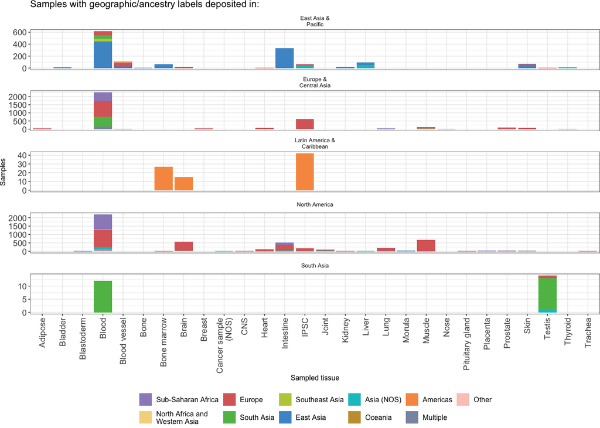

```r
geoTissueFacet <- geographySummary %>% group_by(finalOrgan, strictestGeography, worldRegion) %>% summarise(value = sum(n)) %>% distinct() %>% drop_na(c(finalOrgan, strictestGeography, worldRegion)) %>% as.data.frame %>%
  ggplot(., aes(x = finalOrgan, y = value, fill = strictestGeography)) +
  geom_bar(stat="identity") +
  ggtitle("Samples with geographic/ancestry labels deposited in:") +
  xlab("Sampled tissue") +
  ylab("Samples") +
  scale_fill_geography(name="Population\nDescriptor") +
  guides(fill=guide_legend(title="", nrow=2)) +
  theme(axis.text.x = element_text(angle = 90, hjust=1, vjust=0.5)) +
  theme(legend.title = element_blank(), legend.position="bottom", legend.direction="horizontal") +
  theme(strip.background = element_blank()) +
  facet_wrap(~worldRegion, ncol=1, scales="free_y")
geoTissueFacet
```

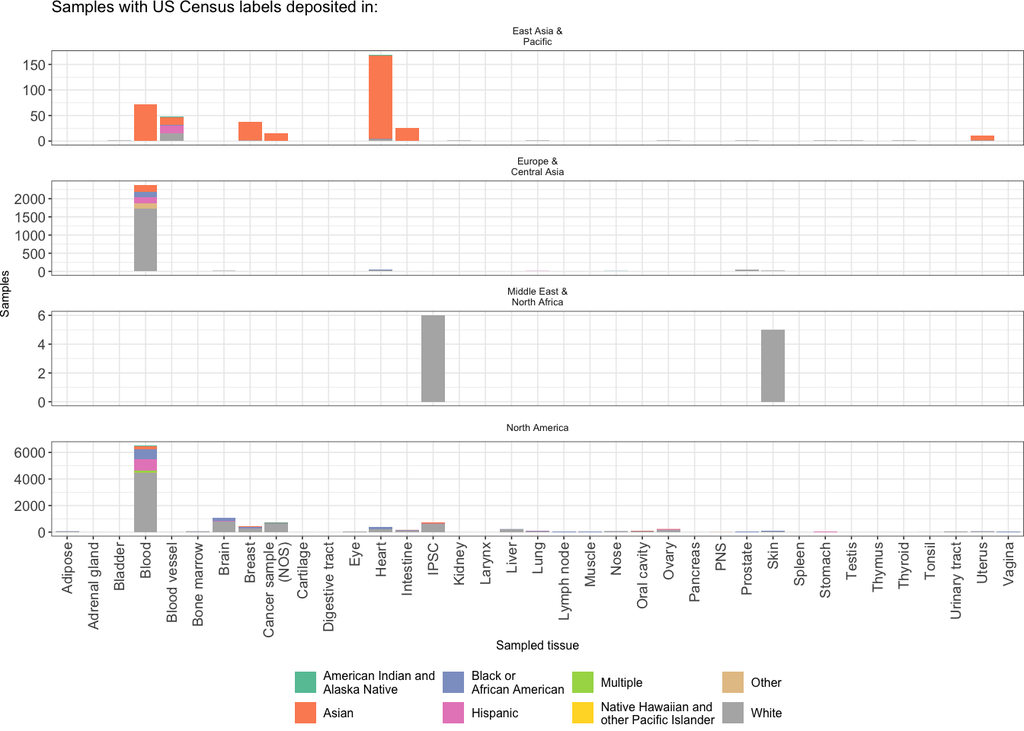

```r
ggsave("fig3_organ_by_geography_faceted.pdf", width=6, height=9)
ggsave("fig3_organ_by_geography_faceted.png", width=6, height=9)

raceTissueFacet <- raceSummary %>% group_by(finalOrgan, strictestRace, worldRegion) %>% summarise(value = sum(n)) %>% distinct() %>% drop_na(c(finalOrgan, strictestRace, worldRegion)) %>% as.data.frame %>%
  ggplot(., aes(x = finalOrgan, y = value, fill = strictestRace)) +
  geom_bar(stat="identity") +
  ggtitle("Samples with US Census labels deposited in:") +
  xlab("Sampled tissue") +
  ylab("Samples") +
  scale_fill_race(name="US Census\nTerm)") +
  guides(fill=guide_legend(title="")) +
  theme(axis.text.x = element_text(angle = 90, hjust=1, vjust=0.5)) +
  theme(legend.title = element_blank(), legend.position="bottom", legend.direction="horizontal") +
  theme(strip.background = element_blank()) +
  facet_wrap(~worldRegion, ncol=1, scales="free_y")
raceTissueFacet
```

```r
ggsave("fig3_organ_by_race_faceted.pdf", width=6, height=9)
ggsave("fig3_organ_by_race_faceted.png", width=6, height=9)
```

And now we should ask, since these proportions look different, are there differences? Is having a given descriptor associated with higher likelihood or something or something else being sequenced?

We can do this at the `hasDescriptor` level (racial vs geographic), at the `finalCountry` level and at the `worldRegion` level, although we also might want to consider the actual descriptors

But first, an easier question: Is blood really more diverse than anything else?

```r
bloodPropGeo <- allSRAFinal %>% filter(grepl("Blood", finalOrgan) & !is.na(strictestGeography)) %>%
  count(strictestGeography) %>%
  mutate(freq = n/sum(n))

nobloodPropGeo <- allSRAFinal %>% filter(!grepl("Blood", finalOrgan) & !is.na(strictestGeography)) %>%
  count(strictestGeography) %>%
  mutate(freq = n/sum(n))

bloodPropRace <- allSRAFinal %>% filter(grepl("Blood", finalOrgan) & !is.na(strictestRace)) %>%
  count(strictestRace) %>%
  mutate(freq = n/sum(n))

nobloodPropRace <- allSRAFinal %>% filter(!grepl("Blood", finalOrgan) & !is.na(strictestRace)) %>%
  count(strictestRace) %>%
  mutate(freq = n/sum(n))

geoBlood <- full_join(bloodPropGeo, nobloodPropGeo, by="strictestGeography", suffix=c("Blood", "NoBlood")) %>%
  full_join(., geographyProp, by="strictestGeography") %>%
  mutate(across(where(is.numeric), ~replace(., is.na(.), 0)))

raceBlood <- full_join(bloodPropRace, nobloodPropRace, by="strictestRace", suffix=c("Blood", "NoBlood")) %>%
  full_join(., raceProp, by="strictestRace") %>%
  mutate(across(where(is.numeric), ~replace(., is.na(.), 0)))

chisq.test(geoBlood[,c(2,6)])
```

```
##
##  Pearson's Chi-squared test
##
## data:  geoBlood[, c(2, 6)]
## X-squared = 509.04, df = 10, p-value < 2.2e-16
```

```r
chisq.test(raceBlood[,c(2,6)])
```

```
##
##  Pearson's Chi-squared test
##
## data:  raceBlood[, c(2, 6)]
## X-squared = 114.6, df = 7, p-value < 2.2e-16
```

```r
# Both are significant but blood is clearly a lot more diverse
geoBlood
```

```
##                strictestGeography nBlood   freqBlood nNoBlood freqNoBlood    n        freq
## 1              Sub-Saharan Africa   1402 0.269252929      292 0.063230836 1694 0.172417303
## 2  North Africa and\nWestern Asia     12 0.002304590        6 0.001299264   18 0.001832061
## 3                          Europe   2194 0.421355867     3275 0.709181464 5469 0.556641221
## 4                      South Asia    693 0.133090071       25 0.005413599  718 0.073078880
## 5                  Southeast Asia     49 0.009410409        0 0.000000000   49 0.004987277
## 6                       East Asia    474 0.091031304      647 0.140103941 1121 0.114096692
## 7                      Asia (NOS)    109 0.020933359      201 0.043525336  310 0.031552163
## 8                        Americas     39 0.007489917      127 0.027501083  166 0.016895674
## 9                        Multiple    180 0.034568850       27 0.005846687  207 0.021068702
## 10                          Other     55 0.010562704        7 0.001515808   62 0.006310433
## 11                        Oceania      0 0.000000000       11 0.002381984   11 0.001119593
```

```r
raceBlood
```

```
##                                 strictestRace nBlood    freqBlood nNoBlood freqNoBlood    n         freq
## 1          American Indian and\nAlaska Native     34 0.0037723289        9 0.001785006   43 0.0030594095
## 2                                       Asian    536 0.0594696549      408 0.080920270  944 0.0671647101
## 3                  Black or\nAfrican American    849 0.0941972706      893 0.177112257 1742 0.1239416578
## 4                                    Hispanic   1056 0.1171640963      199 0.039468465 1255 0.0892920669
## 5                                    Multiple    178 0.0197492511       25 0.004958350  203 0.0144432586
## 6 Native Hawaiian and\nother Pacific Islander      6 0.0006657051        0 0.000000000    6 0.0004268943
## 7                                       Other    155 0.0171973816        7 0.001388338  162 0.0115261473
## 8                                       White   6199 0.6877843115     3501 0.694367315 9700 0.6901458556
```

```r
allPropGeo <- allSRAFinal %>% filter(!is.na(worldRegion)) %>%
  group_by(worldRegion) %>%
  count(finalOrgan) %>%
  as.data.frame()

# Not very promising...
anova(lm(n ~ finalOrgan + worldRegion, data=allPropGeo))
```

```
## Analysis of Variance Table
##
## Response: n
##             Df   Sum Sq Mean Sq F value Pr(>F)
## finalOrgan  44 45284988 1029204  0.9390 0.5823
## worldRegion  5 15606168 3121234  2.8476 0.0303 *
## Residuals   33 36170641 1096080
## ---
## Signif. codes:  0 '***' 0.001 '**' 0.01 '*' 0.05 '.' 0.1 ' ' 1
```

```r
allPropGeo <- allPropGeo %>%
  cast(., worldRegion ~ finalOrgan) %>%
  mutate(across(where(is.numeric), ~replace(., is.na(.), 0)))
# Boring, uninterpretable, cannot be bothered to go any further. Keep it descriptive
chisq.test(allPropGeo[,2:ncol(allPropGeo)])
```

```
##
##  Pearson's Chi-squared test
##
## data:  allPropGeo[, 2:ncol(allPropGeo)]
## X-squared = 19965, df = 225, p-value < 2.2e-16
```